# Final Project

Yueze Xu, Jin Jing, Maolin Hang

4/20/2021

## Goals

The goal of this project is to allow you to practice your analysis, theoretical, and computational skills on a new question. We will be using data from the Reproducibility Project: Psychology, which was an attempt to replicate experiments in Psychology. You can work in groups of up to three people for this project.

1. Read about the project at https://osf.io/447b3/ (the first 28 pages).
2. Pick a study to examine: https://osf.io/ezcuj/wiki/Replicated%20Studies/
- You can consider examining this file: https://osf.io/fgjvw/, which has all of the datasets listed out with the titles and the descriptors to help sort through a topic you might find interesting. Also, not all datasets are good datasets!
3. Read the paper for the replication, specifically focusing on the “target of the study” listed on the replication page. If you have trouble finding the article full-text, please contact me. Try using Google Scholar on the original citation listed in the wiki.
4. Go to the project page and download the data from the project. Make sure it’s raw data that you can import into R.
5. Generate a hypothesis about the data using one of the analyses we’ve discussed (correlation, regression, t-tests, ANOVA).
6. Use the data screening we’ve discussed on the data you are using for the hypothesis (i.e., not the whole dataset).
7. Run the analysis that will answer your hypothesis test.
8. Fill in the following report based on your results.

## Citation of the Study

B Dessalegn, B Landau  
OSF project: https://osf.io/iajp5/  
Final report: https://osf.io/83n4z/  
R script to reproduce key finding: https://osf.io/qmupg/  
DOI: 10.17605/OSF.IO/4KR6E

## Summary of the Study

The original study conducted by Dessalegn and Landau (2008) tried to find out whether language (relational and directional) can help conjunct visual features. In four studies, a sample of four-year-old children were shown a shape split symmetrically into green and red, either vertically, horizontally or diagonally. When instructed with either relational or direcional language describing the color position, children are expected to identify the target in the set.

The replication study focused on the fourth one of the original paper, and tried to arrive at the same findings that directional information in language contributes to the feature binding of color and location information. To replicate, the new study gathered fourty-nine English-speaking 4-year-olds, and performed the trials. In the replicate study, Fitneva used a t-test for the condition effects, rather than the 2x3 ANOVA method used by the original paper. The effect had the same direction as the original one, but it failed to replicate the size and significance.

## Project Hypothesis

### Ho: The condition (directional/relational) has no influence on the accuracy

### Ha: The condition (directional/relational) has some influence on the accuracy

## Part 1: The Data

**We decide to use the whole raw data set from the original project.**  
**We’ve also uploaded the raw file “DATA Binding.xlsx” along with this submission.**

```r
library("xlsx")
library("dplyr")
library("lsr")
my_data<- read.xlsx(file ="DATA Binding.xlsx", 2, header=TRUE)
head(my_data)
```

```
##   Trial      Stim  Time keys SubjNum Condition gender Accuracy.SelectedTarget.
## 1     2       dog  5136    G    1001       dir      m                        0
## 2     3       cat  4047    A    1001       dir      m                        0
## 3     4 diagllAGL 15929    A    1001       dir      m                        1
## 4     5 diagllGLA  4952    G    1001       dir      m                        1
## 5     6 diagllLAG  7032    G    1001       dir      m                        0
## 6     7 diagllALG  4191    G    1001       dir      m                        0
##   SelectedReflection.1.yes. Exclude..1...yes.
## 1                         0                 0
## 2                         1                 0
## 3                         0                 0
## 4                         0                 0
## 5                         0                 0
## 6                         0                 0
```

## Part 2: Data Screening

## Accuracy:

**For categorical variables, we applied factor function to “gender” and “condition”.**

```r
summary(my_data)
```

```
##      Trial          Stim                Time            keys
##  Min.   : 2.0   Length:1440        Min.   :   287   Length:1440
##  1st Qu.:10.0   Class :character   1st Qu.:  3158   Class :character
##  Median :17.5   Mode  :character   Median :  4216   Mode  :character
##  Mean   :17.3                      Mean   :  5495
##  3rd Qu.:25.0                      3rd Qu.:  6011
##  Max.   :32.0                      Max.   :101178
##     SubjNum      Condition            gender          Accuracy.SelectedTarget.
##  Min.   :1001   Length:1440        Length:1440        Min.   :0.0000
##  1st Qu.:1013   Class :character   Class :character   1st Qu.:0.0000
##  Median :1028   Mode  :character   Mode  :character   Median :1.0000
##  Mean   :1046                                         Mean   :0.5736
##  3rd Qu.:1040                                         3rd Qu.:1.0000
##  Max.   :1943                                         Max.   :1.0000
##  SelectedReflection.1.yes. Exclude..1...yes.
##  Min.   :0.0000            Min.   :0.0000
##  1st Qu.:0.0000            1st Qu.:0.0000
##  Median :0.0000            Median :0.0000
##  Mean   :0.2486            Mean   :0.1042
##  3rd Qu.:0.0000            3rd Qu.:0.0000
##  Max.   :1.0000            Max.   :2.0000
```

```r
notypos <- my_data
str(notypos)
```

```
## 'data.frame':    1440 obs. of  10 variables:
##  $ Trial                    : num  2 3 4 5 6 7 9 10 11 12 ...
##  $ Stim                     : chr  "dog" "cat" "diagllAGL" "diagllGLA" ...
##  $ Time                     : num  5136 4047 15929 4952 7032 ...
##  $ keys                     : chr  "G" "A" "A" "G" ...
##  $ SubjNum                  : num  1001 1001 1001 1001 1001 ...
##  $ Condition                : chr  "dir" "dir" "dir" "dir" ...
##  $ gender                   : chr  "m" "m" "m" "m" ...
##  $ Accuracy.SelectedTarget. : num  0 0 1 1 0 0 1 1 1 1 ...
##  $ SelectedReflection.1.yes.: num  0 1 0 0 0 0 0 0 0 0 ...
##  $ Exclude..1...yes.        : num  0 0 0 0 0 0 0 0 0 0 ...
```

```r
##Factor the character vaiables
notypos$gender <- factor(notypos$gender,
                  levels = c("m", "f"),
                  labels = c("Male", "Female"))
notypos$Condition <- factor(notypos$Condition,
                  levels = c("dir", "rel"),
                  labels = c("Directional", "Relational"))

summary(notypos)
```

```
##      Trial          Stim                Time            keys
##  Min.   : 2.0   Length:1440        Min.   :   287   Length:1440
##  1st Qu.:10.0   Class :character   1st Qu.:  3158   Class :character
##  Median :17.5   Mode  :character   Median :  4216   Mode  :character
##  Mean   :17.3                      Mean   :  5495
##  3rd Qu.:25.0                      3rd Qu.:  6011
##  Max.   :32.0                      Max.   :101178
##     SubjNum           Condition      gender    Accuracy.SelectedTarget.
##  Min.   :1001   Directional:960   Male  :870   Min.   :0.0000
##  1st Qu.:1013   Relational :480   Female:570   1st Qu.:0.0000
##  Median :1028                                  Median :1.0000
##  Mean   :1046                                  Mean   :0.5736
##  3rd Qu.:1040                                  3rd Qu.:1.0000
##  Max.   :1943                                  Max.   :1.0000
##  SelectedReflection.1.yes. Exclude..1...yes.
##  Min.   :0.0000            Min.   :0.0000
##  1st Qu.:0.0000            1st Qu.:0.0000
##  Median :0.0000            Median :0.0000
##  Mean   :0.2486            Mean   :0.1042
##  3rd Qu.:0.0000            3rd Qu.:0.0000
##  Max.   :1.0000            Max.   :2.0000
```

## Checking Missing data:

**We use the 5% rule to exclude rows that have missing data.**  
**And the result shows we do not have missing data.**

```r
percentmiss <- function(x) { sum(is.na(x))/length(x) * 100}
#checking the missing value for each row
missing <- apply(notypos, 1, percentmiss)
table(missing)
```

```
## missing
##    0
## 1440
```

## Outliers:

**We removed rows from raw data where participant are marked as “excluded” due to failing the practice and attention problems( Exclude..1..yes = 1)**  
**Also, we only included the data for trails between 9 to 32, which are the experimental trials.**

```r
##remove rows when excluded..1..yes == 1,which participant excluded due to failing practice and attention problems
mydata<-notypos[!notypos$Exclude..1...yes==1,]
##only keep trail number from 9-32 which is named as experimental
mydata<-mydata[notypos$Trial>8,]
summary(mydata)
```

```
##      Trial           Stim                Time            keys
##  Min.   : 9.00   Length:1152        Min.   :   287   Length:1152
##  1st Qu.:14.75   Class :character   1st Qu.:  3069   Class :character
##  Median :20.50   Mode  :character   Median :  4075   Mode  :character
##  Mean   :20.50                      Mean   :  5194
##  3rd Qu.:26.25                      3rd Qu.:  5849
##  Max.   :32.00                      Max.   :101178
##  NA's   :24                         NA's   :24
##     SubjNum           Condition      gender    Accuracy.SelectedTarget.
##  Min.   :1001   Directional:744   Male  :672   Min.   :0.0000
##  1st Qu.:1012   Relational :384   Female:456   1st Qu.:0.0000
##  Median :1027   NA's       : 24   NA's  : 24   Median :1.0000
##  Mean   :1027                                  Mean   :0.6312
##  3rd Qu.:1040                                  3rd Qu.:1.0000
##  Max.   :1053                                  Max.   :1.0000
##  NA's   :24                                    NA's   :24
##  SelectedReflection.1.yes. Exclude..1...yes.
##  Min.   :0.0000            Min.   :0.00000
##  1st Qu.:0.0000            1st Qu.:0.00000
##  Median :0.0000            Median :0.00000
##  Mean   :0.2615            Mean   :0.08511
##  3rd Qu.:1.0000            3rd Qu.:0.00000
##  Max.   :1.0000            Max.   :2.00000
##  NA's   :24                NA's   :24
```

```r
str(mydata)
```

```
## 'data.frame':    1152 obs. of  10 variables:
##  $ Trial                    : num  9 10 11 12 13 14 15 16 17 18 ...
##  $ Stim                     : chr  "diagllLAG" "diagurLGA" "hordnLGA" "vertrLGA" ...
##  $ Time                     : num  7544 2991 6169 3535 13025 ...
##  $ keys                     : chr  "L" "L" "L" "L" ...
##  $ SubjNum                  : num  1001 1001 1001 1001 1001 ...
##  $ Condition                : Factor w/ 2 levels "Directional",..: 1 1 1 1 1 1 1 1 1 1 ...
##  $ gender                   : Factor w/ 2 levels "Male","Female": 1 1 1 1 1 1 1 1 1 1 ...
##  $ Accuracy.SelectedTarget. : num  1 1 1 1 1 1 1 1 0 1 ...
##  $ SelectedReflection.1.yes.: num  0 0 0 0 0 0 0 0 1 0 ...
##  $ Exclude..1...yes.        : num  0 0 0 0 0 0 0 0 0 0 ...
```

# Assumptions:

## Linearity:

**The dots within the (-2, 2) range are along the linear line. Linearity assumption met.**

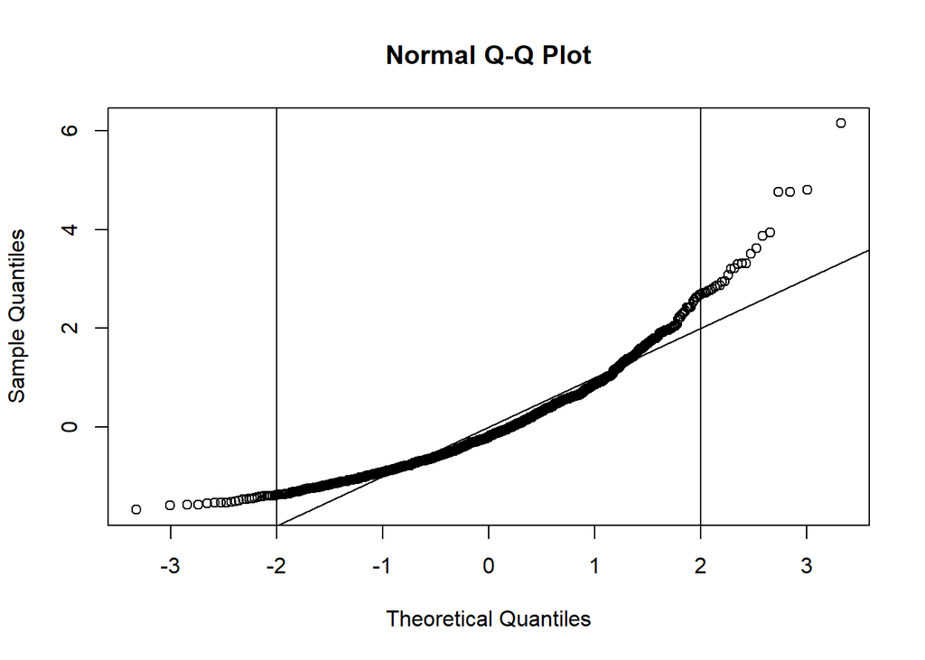

```r
random <- rchisq(nrow(mydata), 6) #lucky number 6
fake <- lm(random ~ ., data = mydata)
standardized <- rstudent(fake)
fittedvalues <- scale(fake$fitted.values)

{qqnorm(standardized)
  abline(0,1)
  abline(v = -2)
  abline(v = 2)}
```

## Normality:

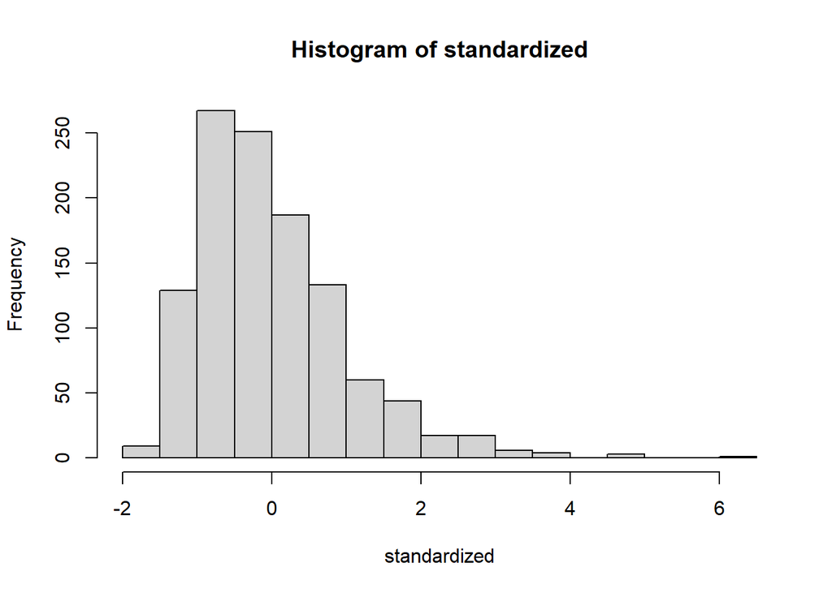

```r
hist(standardized, breaks = 15)
```

## Homogeneity/Homoscedasticity:

**The spread above 0 and below in both horizontal and vertical directions are relatively equal. The spread across X axis is quite even. Assumption met.**

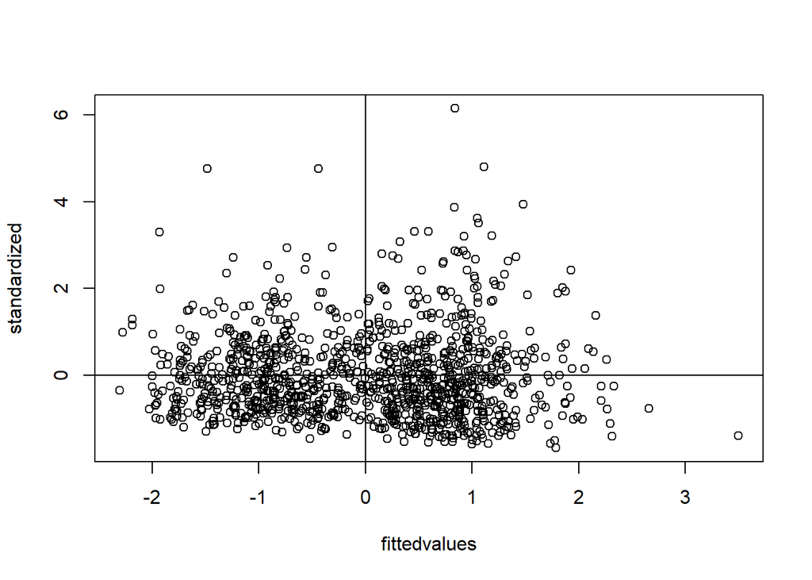

```r
{plot(fittedvalues, standardized)
  abline(h = 0)
  abline(v = 0)}
```

## Data exploration:

**We grouped each subject (participant) to calculate their average accuracy score.**

```r
##we use dplyr package function to create a new data set, witch including SujNum, Condition, and Average points of the accuracy for each child.
dat <- mydata %>%
  group_by(SubjNum, Condition) %>%
  dplyr::summarize(avgAcc = mean(Accuracy.SelectedTarget.))
head(dat)
```

```
## # A tibble: 6 x 3
## # Groups:   SubjNum [6]
##   SubjNum Condition   avgAcc
##     <dbl> <fct>        <dbl>
## 1    1001 Directional  0.917
## 2    1002 Directional  0.833
## 3    1003 Relational   0.375
## 4    1004 Directional  0.375
## 5    1005 Directional  0.875
## 6    1006 Relational   0.875
```

## Part 3: The Analysis

**We decided to use T-Test to test our null hypothesis.**

```r
ttest<-t.test(avgAcc ~ Condition, dat, var.equal = TRUE, paired = FALSE)
ttest
```

```
##
##  Two Sample t-test
##
## data:  avgAcc by Condition
## t = 1.5339, df = 45, p-value = 0.1321
## alternative hypothesis: true difference in means is not equal to 0
## 95 percent confidence interval:
##  -0.0264290  0.1952798
## sample estimates:
## mean in group Directional  mean in group Relational
##                 0.6599462                 0.5755208
```

```r
#t statistics
ttest$statistic
```

```
##        t
## 1.533917
```

```r
#p-value
ttest$p.value
```

```
## [1] 0.1320514
```

```r
#sample size
nrow(dat)
```

```
## [1] 48
```

```r
#effect size
cohensD(dat$avgAcc[dat$Condition == "Directional"], dat$avgAcc[dat$Condition == "Relational"])
```

```
## [1] 0.4721827
```

## Summarize

From the given information in the original and replicate study, the focal point was to find out whether a directional or relational language can help conjunct visual features. The conjunction was measured by “accuracy” where 1 = child successfully identified the target pattern, and 0 = failure.

Without further information, we formed our hypothesis to test this very finding.

Null hypothesis: The condition (directional/relational) has no influence on the accuracy  
Alternative hypothesis: The condition (directional/relational) has some influence on the accuracy

We decided to use T-test to test our hypothesis.

Each participant was recorded with practice (trial 2 to 7) and experimental (trial 9 to 32) results. For the purpose of this test, we kept only the experimental trials.

The raw data was already in a long format, so we grouped the data by SubjNum (participant) and calculated the average accuracy score for each person. Since each participant was given only one type of language condition, the two groups are independent.

We then perform the T-test on “average accuracy” for the two different “condition” groups. We chose 0.05 as our critical value.